# Tugas Praktikum 3

Irsyad Fariz Sena Pratama

2025-09-12

```r
# Membaca file CSV
df <- read.csv("~/NewDelhi_Air_quality.csv", header = TRUE, sep = ",")

# Cek struktur data
str(df)
```

```
## 'data.frame':    72 obs. of  12 variables:
##  $ X              : int  0 1 2 3 4 5 6 7 8 9 ...
##  $ AQI            : num  30.2 28.2 26.6 25 26 26 26 24 23 24 ...
##  $ CO             : num  199 198 199 202 205 ...
##  $ datetime       : chr  "2022-10-21:18" "2022-10-21:19" "2022-10-21:20" "2022-10-21:21" ...
##  $ no2            : num  0.0469 0.0465 0.0469 0.0482 0.0489 ...
##  $ o3             : num  55.8 54.9 54.6 55.1 55.8 ...
##  $ pm10           : num  10.5 10.7 11.2 11.1 10.4 ...
##  $ pm25           : num  5.64 4.62 3.52 2.23 1.98 ...
##  $ so2            : num  0.387 0.41 0.402 0.376 0.339 ...
##  $ timestamp_local: chr  "2022-10-21T23:00:00" "2022-10-22T00:00:00" "2022-10-22T01:00:00" "2022-10-22T02:00:00" ...
##  $ timestamp_utc  : chr  "2022-10-21T18:00:00" "2022-10-21T19:00:00" "2022-10-21T20:00:00" "2022-10-21T21:00:00" ...
##  $ ts             : int  1666375200 1666378800 1666382400 1666386000 1666389600 1666393200 1666396800 1666400400 1666404000 1666407600 ...
```

```r
# Lihat beberapa baris pertama
head(df)
```

```
##   X  AQI       CO      datetime        no2       o3      pm10     pm25
## 1 0 30.2 198.6027 2022-10-21:18 0.04685717 55.78995 10.486722 5.637410
## 2 1 28.2 197.6013 2022-10-21:19 0.04645554 54.93164 10.719325 4.618169
## 3 2 26.6 198.6027 2022-10-21:20 0.04685717 54.64554 11.155578 3.520902
## 4 3 25.0 201.9405 2022-10-21:21 0.04819594 55.07469 11.116206 2.225919
## 5 4 26.0 205.2784 2022-10-21:22 0.04886533 55.78995 10.405250 1.979471
## 6 5 26.0 208.6163 2022-10-21:23 0.05020411 56.50520  9.402518 1.792677
##         so2     timestamp_local       timestamp_utc         ts
## 1 0.3874302 2022-10-21T23:00:00 2022-10-21T18:00:00 1666375200
## 2 0.4097819 2022-10-22T00:00:00 2022-10-21T19:00:00 1666378800
## 3 0.4023313 2022-10-22T01:00:00 2022-10-21T20:00:00 1666382400
## 4 0.3762543 2022-10-22T02:00:00 2022-10-21T21:00:00 1666386000
## 5 0.3390014 2022-10-22T03:00:00 2022-10-21T22:00:00 1666389600
## 6 0.3129244 2022-10-22T04:00:00 2022-10-21T23:00:00 1666393200
```

# Pemilihan Peubah X berdasarkan Korelasi dengan Peubah Y

```r
# Hitung korelasi antar semua peubah
cor(df[, c("AQI", "CO", "no2", "o3", "pm10", "pm25", "so2")], method = "pearson")
```

```
##              AQI          CO        no2          o3        pm10       pm25
## AQI   1.00000000  0.79763320  0.7376547  0.97359901  0.08257568 -0.3466552
## CO    0.79763320  1.00000000  0.6520228  0.82919809 -0.09598578 -0.5829151
## no2   0.73765472  0.65202279  1.0000000  0.73204188  0.25652368 -0.3588091
## o3    0.97359901  0.82919809  0.7320419  1.00000000  0.03381079 -0.5219779
## pm10  0.08257568 -0.09598578  0.2565237  0.03381079  1.00000000  0.2684827
## pm25 -0.34665524 -0.58291511 -0.3588091 -0.52197786  0.26848271  1.0000000
## so2  -0.74247813 -0.79872002 -0.5859130 -0.78562485 -0.04779446  0.6743428
##              so2
## AQI  -0.74247813
## CO   -0.79872002
## no2  -0.58591304
## o3   -0.78562485
## pm10 -0.04779446
## pm25  0.67434283
## so2   1.00000000
```

```r
# Kalau hanya mau korelasi AQI dengan variabel lain
cor(df$AQI, df$CO, method = "pearson")
```

```
## [1] 0.7976332
```

```r
cor(df$AQI, df$no2, method = "pearson")
```

```
## [1] 0.7376547
```

```r
cor(df$AQI, df$o3, method = "pearson")
```

```
## [1] 0.973599
```

```r
cor(df$AQI, df$pm10, method = "pearson")
```

```
## [1] 0.08257568
```

```r
cor(df$AQI, df$pm25, method = "pearson")
```

```
## [1] -0.3466552
```

```r
cor(df$AQI, df$so2, method = "pearson")
```

```
## [1] -0.7424781
```

Pemilihan O₃ didasarkan pada hasil analisis korelasi antara AQI dengan beberapa polutan lain, yaitu CO, NO₂, PM₁₀, PM₂.₅, dan SO₂. Hasil perhitungan menunjukkan bahwa O₃ memiliki nilai korelasi tertinggi dengan AQI, yaitu sebesar 0,97, yang berarti terdapat hubungan linear yang sangat kuat dan positif antara O₃ dan AQI. Korelasi yang tinggi ini mengindikasikan bahwa perubahan konsentrasi O₃ sangat memengaruhi perubahan nilai AQI dibandingkan dengan polutan lainnya.

# Eksplorasi Data

```r
# Buat time series hanya untuk AQI dan O3
data.ts <- ts(df[, c("AQI", "o3")], frequency = 24, start = c(2022, 1))
```

```r
View(data.ts)
str(data.ts)
```

```
##  Time-Series [1:72, 1:2] from 2022 to 2025: 30.2 28.2 26.6 25 26 26 26 24 23 24 ...
##  - attr(*, "dimnames")=List of 2
##   ..$ : NULL
##   ..$ : chr [1:2] "AQI" "o3"
```

```r
dim(data.ts)
```

```
## [1] 72  2
```

```r
summary(data.ts)
```

```
##       AQI              o3
##  Min.   :19.00   Min.   :41.48
##  1st Qu.:25.00   1st Qu.:53.64
##  Median :27.00   Median :57.22
##  Mean   :26.18   Mean   :56.57
##  3rd Qu.:28.00   3rd Qu.:60.08
##  Max.   :32.00   Max.   :68.66
```

# Uji Asumsi

```r
# Model sederhana: AQI dipengaruhi oleh O3
model1 <- lm(AQI ~ o3, data = df)
```

## Uji Normalitas

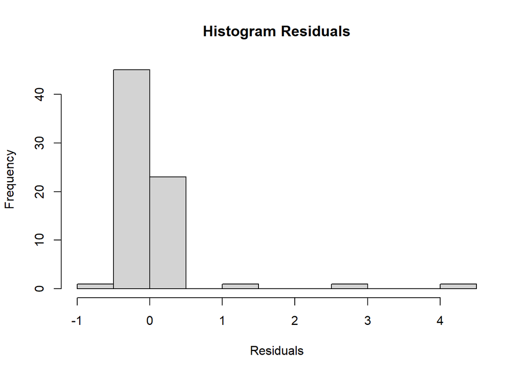

```r
res <- residuals(model1)

# Histogram residual
hist(res, main="Histogram Residuals", xlab="Residuals")
```

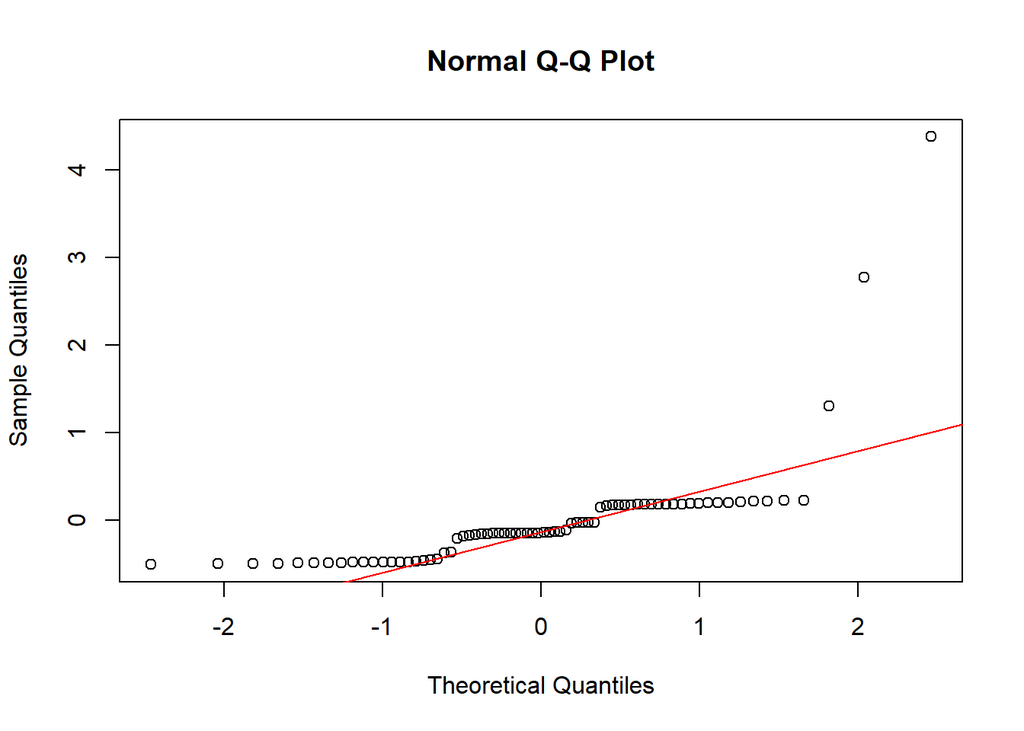

```r
# QQ-plot residual
qqnorm(res); qqline(res, col="red")
```

```r
# Shapiro-Wilk Test
shapiro.test(res)
```

```
##
##  Shapiro-Wilk normality test
##
## data:  res
## W = 0.51931, p-value = 5.517e-14
```

## Uji Heteroskedastisitas

```r
library(lmtest)
bptest(model1)   # Breusch-Pagan Test
```

```
##
##  studentized Breusch-Pagan test
##
## data:  model1
## BP = 0.039736, df = 1, p-value = 0.842
```

## Uji Autokorelasi

```r
library(car)
durbinWatsonTest(model1)  # Durbin-Watson test
```

```
##  lag Autocorrelation D-W Statistic p-value
##    1       0.4485567     0.5463596       0
##  Alternative hypothesis: rho != 0
```

Berdasarkan hasil uji asumsi klasik, diketahui bahwa residual model tidak berdistribusi normal (p-value Shapiro-Wilk < 0.05), tidak terdapat indikasi heteroskedastisitas (p-value Breusch-Pagan > 0.05), namun terdapat autokorelasi positif yang signifikan pada residual (p-value Durbin-Watson < 0.05). Dengan demikian, asumsi normalitas dan bebas autokorelasi tidak terpenuhi, sedangkan asumsi homoskedastisitas terpenuhi.